# Seattle Link Light-Rail Network Analysis

Albany Garcia

2025-06-06

# Summary

This project explores Seattle’s Link light-rail system using network analysis. By treating stations as nodes and their direct connections as edges, we identify the busiest transfer hubs, uncover regional clusters, simulate future extensions, and lay the groundwork for comparing these insights to ridership patterns.

**Goals:**

- Quantify station importance using degree centrality
- Reveal natural station groupings with community detection
- Measure how adding the Everett extension shifts network flow
- Prepare the network model for future ridership comparisons

# Setup

```r
packages <- c("dplyr", "readr", "igraph", "sf", "ggraph", "scales")
installed <- packages %in% installed.packages()[, "Package"]
if (any(!installed)) install.packages(packages[!installed])
lapply(packages, library, character.only = TRUE)
```

[output not shown]

# Data Description

All datasets below are **publicly available**

- **Stations**
  - **Source:** [light_rail_stations.csv](https://data-seattlecitygis.opendata.arcgis.com/datasets/SeattleCityGIS%3A%3Alight-rail-stations-1) (Seattle Open Data)
  - **Columns:** `stop_id`, `stop_name`, `stop_lat`, `stop_lon`
  - **Data Collected:** Updated **May 23, 2024**
  - **Description:** Each row represents a Link station (node) with its unique ID, official name, and geographic coordinates.
- **Stop Times**
  - **Source:** [stop_times.txt](https://www.soundtransit.org/help-contacts/business-information/open-transit-data-otd/otd-downloads) (Sound Transit GTFS static feed)
  - **Columns:** `trip_id`, `arrival_time`, `departure_time`, `stop_id`, `stop_sequence`
  - **Data Collected:** GTFS feed effective **June 1, 2025**
  - **Description:** Ordered list of stops for each train trip—used to infer edges between consecutive stations.
- **Trips**
  - **Source:** [trips.txt](https://www.soundtransit.org/help-contacts/business-information/open-transit-data-otd/otd-downloads) (Sound Transit GTFS static feed)
  - **Columns:** `route_id`, `service_id`, `trip_id`, `trip_headsign`, `direction_id`, `shape_id`
  - **Data Collected:** GTFS feed effective **June 1, 2025**
  - **Description:** Metadata for each trip, including which route and direction it serves—optional for annotating or filtering edges by line.

```r
stations <- read_csv("light_rail_stations.csv")
stop_times <- read_csv("stop_times.txt")
trips <- read_csv("trips.txt")
```

# Create Graph

```r
edges <- stop_times %>%
  arrange(trip_id, stop_sequence) %>%
  group_by(trip_id) %>%
  mutate(next_stop = lead(stop_id)) %>%
  ungroup() %>%
  filter(!is.na(next_stop)) %>%
  select(from = stop_id, to = next_stop)

# 4. Construct the igraph object
g <- graph_from_data_frame(edges, directed = FALSE)

# 5. Compute centrality and community
V(g)$degree      <- degree(g)
V(g)$betweenness <- betweenness(g)
clusters         <- cluster_fast_greedy(g)
V(g)$community   <- membership(clusters)

g
```

```
## IGRAPH b9ab441 UN-- 11 10 --
## + attr: name (v/c), degree (v/n), betweenness (v/n), community (v/n)
## + edges from b9ab441 (vertex names):
##  [1] AngleLake   --SeaTac       SeaTac      --Tukwila
##  [3] Tukwila     --RainierBeach RainierBeach--MountBaker
##  [5] MountBaker  --IntlDistrict IntlDistrict--Westlake
##  [7] Westlake    --UStreet      UStreet     --Roosevelt
##  [9] Roosevelt   --Northgate    Northgate   --Lynnwood
```

# Network Visualization

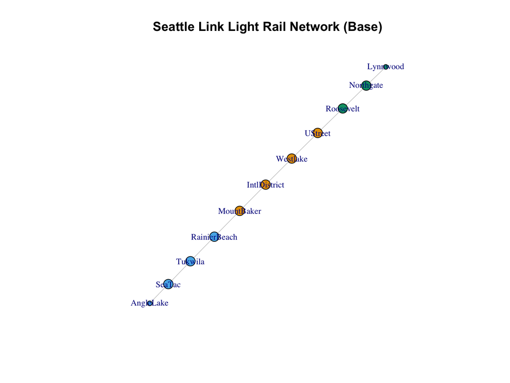

```r
plot(
  g,
  vertex.label     = V(g)$name,
  vertex.label.cex = 0.8,
  vertex.size      = V(g)$degree * 4,
  vertex.color     = V(g)$community,
  edge.width       = 0.5,
  main             = "Seattle Link Light Rail Network (Base)"
)
```

# Everett Extension Simulation

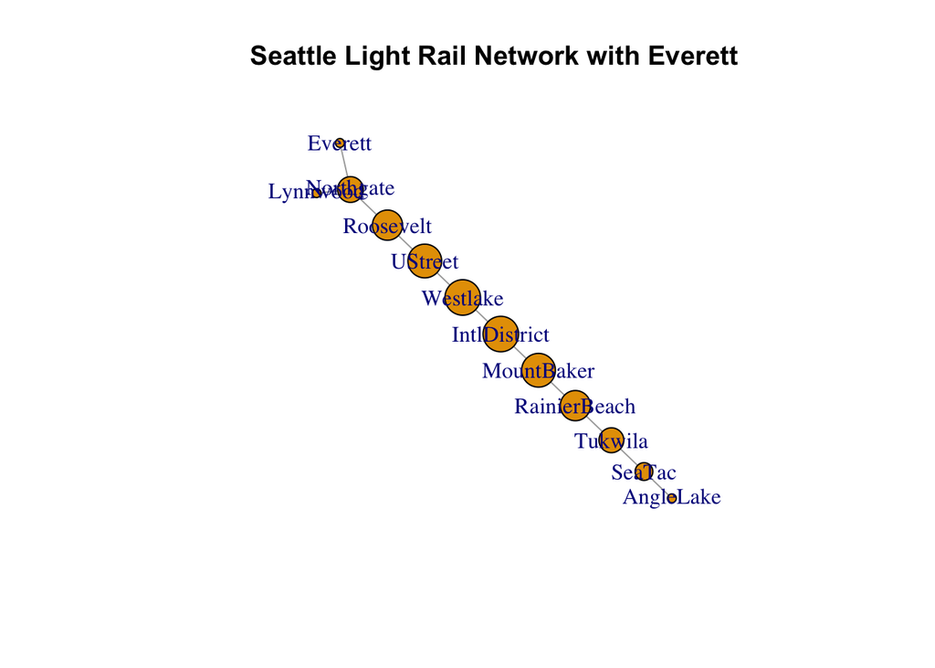

```r
g_expanded <- g
g_expanded <- add_vertices(g_expanded, nv = 1, name = "Everett")
g_expanded <- add_edges(g_expanded, c("Northgate", "Everett"))

# Recompute betweenness and rescale for plotting
bet_after    <- betweenness(g_expanded)
scaled_size  <- rescale(bet_after, to = c(5, 20))

plot(
  g_expanded,
  vertex.label = V(g_expanded)$name,
  vertex.size  = scaled_size,
  edge.width   = 1,
  main         = "Seattle Light Rail Network with Everett"
)
```

# Analyze

```r
library(knitr)
centrality_df <- tibble(
  station      = V(g)$name,
  degree       = V(g)$degree,
  betweenness  = V(g)$betweenness,
  community    = V(g)$community
) %>%
  arrange(desc(degree))

kable(head(centrality_df, 10),
      caption = "Top 10 Stations by Degree Centrality")
```

Top 10 Stations by Degree Centrality

| station | degree | betweenness | community |
| --- | --- | --- | --- |
| SeaTac | 2 | 9 | 2 |
| Tukwila | 2 | 16 | 2 |
| RainierBeach | 2 | 21 | 2 |
| MountBaker | 2 | 24 | 1 |
| IntlDistrict | 2 | 25 | 1 |
| Westlake | 2 | 24 | 1 |
| UStreet | 2 | 21 | 1 |
| Roosevelt | 2 | 16 | 3 |
| Northgate | 2 | 9 | 3 |
| AngleLake | 1 | 0 | 2 |

# Conclusion